# Análise de Correlação Canônica

Maria Nilza Ramos

2026-01-29

Pacotes usados:

```r
# Carregar pacotes necessários
library(readr)
library(CCA)
library(CCP)
```

## Questão 1

Definição dos dados:

```r
data <- data.frame(
  Pessoa = 1:46,
  y1 = c(0.81, 0.95, 0.94, 1.04, 1.00, 0.76, 0.91, 1.10, 0.99, 0.78, 0.90, 0.73, 0.96, 0.84, 0.74, 0.98, 1.10, 0.85, 0.83, 0.93, 0.95, 0.74, 0.95, 0.97, 0.72, 1.11, 1.20, 1.13, 1.00, 0.78, 1.00, 1.00, 0.71, 0.76, 0.89, 0.88, 1.17, 0.85, 0.97, 1.00, 1.00, 0.89, 0.98, 0.78, 0.74, 0.91),
  y2 = c(80, 97, 105, 90, 90, 86, 100, 85, 97, 97, 91, 87, 78, 90, 86, 80, 90, 99, 85, 90, 90, 88, 95, 90, 92, 74, 98, 100, 86, 98, 70, 99, 75, 90, 85, 99, 100, 78, 106, 98, 102, 90, 94, 80, 93, 86),
  x1 = c(356, 289, 319, 356, 323, 381, 350, 301, 379, 296, 353, 306, 290, 371, 312, 393, 364, 359, 296, 345, 378, 304, 347, 327, 386, 365, 365, 352, 325, 321, 360, 336, 352, 353, 373, 376, 367, 335, 396, 277, 378, 360, 291, 269, 318, 328),
  x2 = c(124, 117, 143, 199, 240, 157, 221, 186, 142, 131, 221, 178, 136, 200, 208, 202, 152, 185, 116, 123, 136, 134, 184, 192, 279, 228, 145, 172, 179, 222, 134, 143, 169, 263, 174, 134, 182, 241, 128, 222, 165, 282, 94, 121, 73, 106),
  x3 = c(55, 76, 105, 108, 143, 165, 119, 105, 98, 94, 53, 66, 142, 93, 68, 102, 76, 37, 60, 50, 47, 50, 91, 124, 74, 235, 158, 140, 145, 99, 90, 105, 32, 165, 78, 80, 54, 175, 80, 186, 117, 160, 71, 29, 42, 56)
)

X <- data[, c("x1", "x2", "x3")]  # Variáveis do grupo 1
Y <- data[, c("y1", "y2")]        # Variáveis do grupo 2
```

Realizar a acc:

```r
cc <- CCA::cc(X, Y)

xcoef <- cc$xcoef
ycoef <- cc$ycoef

stdcoef_X <- CCA::comput(X, Y, cc)$coef$xscores;stdcoef_X
```

[output not shown]

```r
stdcoef_Y <- CCA::comput(X, Y, cc)$coef$yscores;stdcoef_Y
```

[output not shown]

```r
summary(cc)
```

```
##        Length Class  Mode
## cor    2      -none- numeric
## names  3      -none- list
## xcoef  6      -none- numeric
## ycoef  4      -none- numeric
## scores 6      -none- list
```

###### Foram calculados também os coeficientes canônicos padronizados, de modo a eliminar o efeito das diferentes escalas das variáveis. Esses coeficientes permitem interpretar corretamente quais variáveis contribuem mais para cada variável canônica.

### As correlações canônicas entre (y1, y2) e (x1, x2, x3):

```r
v.ca <- cc$cor
v.ca
```

```
## [1] 0.5142050 0.1254881
```

## Os coeficientes:

```r
xcoef <- cc$xcoef
ycoef <- cc$ycoef
```

##### Primeiro par de variáveis canônicas

```
## x1: -0.0131025 contribuição negativa
```

```
## x2: 0.0144329 contribuição positiva
```

```
## x3: -0.02339254 contribuição negativa
```

```
## y1: -8.018134 contribuição negativa significativa
```

```
## y2: 0.01898465 contribuição positiva muito pequena
```

##### Segundo par de variáveis canônicas

```
## x1: 0.02474537 contribuição positiva
```

```
## x2: -0.009317405 contribuição negativa
```

```
## x3: -0.008669523 contribuição negativa
```

```
## y1: -0.3751775 contribuição negativa moderada
```

```
## y2: 0.1200671 contribuição positiva moderada
```

##### As primeiras variáveis canônicas são medidas medianas resumidas de seus respectivos conjuntos de variáveis, pois a força da relação linear das combinações do primeiro conjunto é 0,51, um valor moderado. O segundo par (Y) possui relação fraca de combinações lineares entre seu grupo com uma correlação de 0,13. Podemos ver visualmente pelo gráfico da dimensão abaixo:

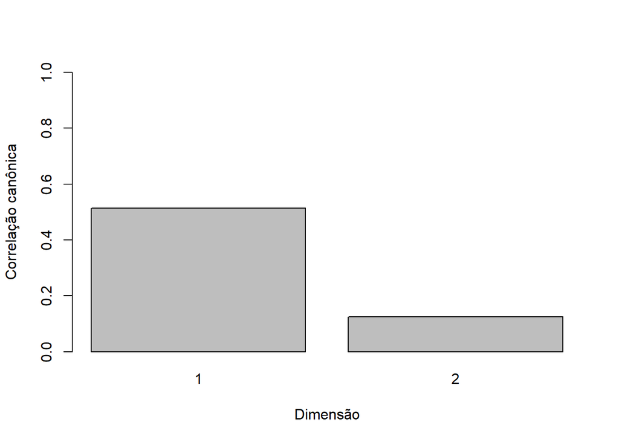

```r
barplot(v.ca, xlab = "Dimensão", ylab = "Correlação canônica", names.arg = 1:length(v.ca), ylim = c(0, 1))
```

### Testar a significância das correlações

```r
n <- nrow(X)
p <- ncol(X)
q <- ncol(Y)
rho <- cc$cor

wilks_test <- CCP::p.asym(rho, n, p, q, tstat = "Wilks")
```

```
## Wilks' Lambda, using F-approximation (Rao's F):
##               stat    approx df1 df2    p.value
## 1 to 2:  0.7240096 2.3949935   6  82 0.03499556
## 2 to 2:  0.9842527 0.3359836   2  42 0.71653789
```

```r
pillai_test <- CCP::p.asym(rho, n, p, q, tstat = "Pillai")
```

```
##  Pillai-Bartlett Trace, using F-approximation:
##                stat    approx df1 df2    p.value
## 1 to 2:  0.28015406 2.2805280   6  84 0.04347734
## 2 to 2:  0.01574727 0.3491894   2  88 0.70623228
```

```r
hotelling_test <- CCP::p.asym(rho, n, p, q, tstat = "Hotelling")
```

```
##  Hotelling-Lawley Trace, using F-approximation:
##                stat    approx df1 df2    p.value
## 1 to 2:  0.37544623 2.5029749   6  80 0.02854533
## 2 to 2:  0.01599922 0.3359836   2  84 0.71559077
```

```r
roy_test <- CCP::p.asym(rho, n, p, q, tstat = "Roy")
```

```
##  Roy's Largest Root, using F-approximation:
##               stat   approx df1 df2     p.value
## 1 to 1:  0.2644068 7.728111   2  43 0.001357409
##
##  F statistic for Roy's Greatest Root is an upper bound.
```

```r
# Exibir testes
#wilks_test
#pillai_test
#hotelling_test
#roy_test

fim <- data.frame(
  Test = c("Wilks' Lambda", "Pillai-Bartlett Trace", "Hotelling-Lawley Trace", "Roy's Largest Root"),
  `Primeira CC` = c(ifelse(wilks_test$p.value[1] < 0.05, "Rejeita H0", "Não Rejeita H0"),
                                     ifelse(pillai_test$p.value[1] < 0.05, "Rejeita H0", "Não Rejeita H0"),
                                     ifelse(hotelling_test$p.value[1] < 0.05, "Rejeita H0", "Não Rejeita H0"),
                                     ifelse(roy_test$p.value[1] < 0.05, "Rejeita H0", "Não Rejeita H0")),
  `Segunda CC` = c(ifelse(wilks_test$p.value[2] < 0.05, "Rejeita H0", "Não Rejeita H0"),
                                    ifelse(pillai_test$p.value[2] < 0.05, "Rejeita H0", "Não Rejeita H0"),
                                    ifelse(hotelling_test$p.value[2] < 0.05, "Rejeita H0", "Não Rejeita H0"),
                                    ifelse(length(roy_test$p.value) > 1 && roy_test$p.value[2] < 0.05, "Rejeita H0", "Não Rejeita H0"))
)
fim
```

```
##                     Test Primeira.CC     Segunda.CC
## 1          Wilks' Lambda  Rejeita H0 Não Rejeita H0
## 2  Pillai-Bartlett Trace  Rejeita H0 Não Rejeita H0
## 3 Hotelling-Lawley Trace  Rejeita H0 Não Rejeita H0
## 4     Roy's Largest Root  Rejeita H0 Não Rejeita H0
```

##### Conclui-se que apenas a primeira correlação canônica é estatisticamente significativa, enquanto a segunda não é

### Correlações das variáveis canônicas com as variáveis originais

```r
cargas <- CCA::comput(X, Y, cc)
```

```
##          Variavel_Original      Variavel_Canonica  Correlacao       Forca
## 1            x1 (glicemia) Primeira canônica de X -0.33990380   Não forte
## 2            x2 (glicemia) Primeira canônica de X  0.05020193   Não forte
## 3  x3 (níveis de insulina) Primeira canônica de X -0.75515753       Forte
## 4       y1 (peso relativo) Primeira canônica de X -0.50789526   Não forte
## 5            y2 (glicemia) Primeira canônica de X -0.02403393   Não forte
## 6            x1 (glicemia)  Segunda canônica de X  0.68372080       Forte
## 7            x2 (glicemia)  Segunda canônica de X -0.45655180   Não forte
## 8  x3 (níveis de insulina)  Segunda canônica de X -0.57302670   Não forte
## 9       y1 (peso relativo) Primeira canônica de Y  0.01959833   Não forte
## 10           y2 (glicemia) Primeira canônica de Y  0.12535099   Não forte
## 11           x1 (glicemia)  Segunda canônica de Y -0.17478024   Não forte
## 12           x2 (glicemia)  Segunda canônica de Y  0.08579885   Não forte
## 13 x3 (níveis de insulina)  Segunda canônica de Y -0.38830578   Não forte
## 14      y1 (peso relativo) Primeira canônica de Y -0.98772912 Muito forte
## 15           y2 (glicemia) Primeira canônica de Y  0.15617680   Não forte
## 16      y1 (peso relativo)  Segunda canônica de Y -0.04673998   Não forte
## 17           y2 (glicemia)  Segunda canônica de Y  0.99890710 Muito forte
```

##### Com base nessas correlações, observamos que a variável x3 (níveis de insulina) tem uma correlação negativa forte com a primeira variável canônica de X, enquanto y1 (peso relativo) e y2 (glicemia) têm correlações muito fortes com a primeira e segunda variáveis canônicas de Y, respectivamente.

```r
pvte.u <- (colSums((cargas$corr.X.xscores)^2)) / (dim(X)[2]) * 100
pvte.v <- (colSums((cargas$corr.Y.yscores)^2)) / (dim(Y)[2]) * 100

pvte.u
```

```
## [1] 22.94392 33.47578
```

```r
pvte.v
```

```
## [1] 48.88967 51.11033
```

#### Para o conjunto X:

##### A primeira variável canônica de X explica 22.94% da variância total das variáveis de X.

##### A segunda variável canônica de X explica 33.48% da variância total das variáveis de X.

#### Para o conjunto Y:

##### A primeira variável canônica de Y explica 48.89% da variância total das variáveis de Y.

##### A segunda variável canônica de Y explica 51.11% da variância total das variáveis de Y.

## Questão 2

Importação dos dados:

```r
library(readr)
dados <- read_delim("T7-7.dat", delim = "\t", col_names = FALSE,show_col_types = FALSE)
X <- dados[, 1:4]
Z <- dados[, 5:8]
```

#### As variáveis canônicas padronizadas da amostra e suas correlações:

```r
# Padronizar
X_std <- scale(X)
Z_std <- scale(Z)

cc <- CCA::cc(X_std, Z_std)

cc$xcoef
```

```
##          [,1]      [,2]      [,3]       [,4]
## X1  1.5054030 -3.495619  5.701510  5.0848285
## X2  0.2119308 -1.543068 -3.525176  0.5867306
## X3 -1.9983550  1.075969  4.713469 -6.0693882
## X4 -0.6764123  3.767929 -7.153231  0.6860659
```

```r
cc$ycoef
```

```
##          [,1]         [,2]        [,3]        [,4]
## X5  0.1592987  0.688585352  0.51296647 -2.33302308
## X6 -0.6324836  1.002946091 -0.07719359  2.18025545
## X7 -0.3249077  0.005010694  1.66312823 -0.02222949
## X8 -0.8178993 -1.561861202  0.77858566 -0.08914213
```

```r
cargas <- CCA::comput(X_std, Z_std, cc)

variaveis_canonicas_X <- cargas$corr.X.xscores
variaveis_canonicas_Z <- cargas$corr.Y.xscores

pvte.u <- (colSums((cargas$corr.X.xscores)^2)) / ncol(X) * 100
pvte.v <- (colSums((cargas$corr.Y.yscores)^2)) / ncol(Z) * 100


variaveis_canonicas_X <- cargas$corr.X.xscores;variaveis_canonicas_X
```

```
##          [,1]        [,2]        [,3]      [,4]
## X1 -0.9350634 -0.12605131  0.05338394 0.3269827
## X2 -0.8869185 -0.42797268 -0.13055874 0.1147575
## X3 -0.9767068 -0.14531583  0.03066752 0.1548759
## X4 -0.9517945  0.01468633 -0.01269887 0.3061214
```

```r
variaveis_canonicas_Z <- cargas$corr.Y.xscores;variaveis_canonicas_Z
```

```
##          [,1]        [,2]        [,3]        [,4]
## X5 -0.7490811  0.30089455 -0.04409315 -0.03779272
## X6 -0.8307275  0.31437367 -0.04721386  0.00115791
## X7  0.5959272  0.01002297  0.19398100  0.01913368
## X8 -0.8617892 -0.18848365 -0.04913553 -0.01585693
```

#### Além das cargas canônicas, foram exibidos os coeficientes canônicos brutos e padronizados. Os coeficientes padronizados permitem identificar diretamente quais variáveis originais mais contribuem para a formação das variáveis canônicas, eliminando o efeito da escala de medição.

##### Só a primeira coluna apresenta valores de correlações fortes, mostrando que as primeiras variáveis canônicas de X e Z têm correlações fortes com as variáveis originais. As demais são fracas ou moderadas.

```r
pvte.u <- (colSums((cargas$corr.X.xscores)^2)) / (dim(X)[2]) * 100
pvte.v <- (colSums((cargas$corr.Y.yscores)^2)) / (dim(Z)[2]) * 100

pvte.u
```

```
## [1] 88.0209266  5.5095481  0.5249297  5.9445956
```

```r
pvte.v
```

```
## [1] 69.787877  8.428421 15.695253  6.088449
```

#### As primeiras variáveis canônicas (U1 e V1) têm correlações forte a moderada com a maioria das variáveis originais, além disso, a primeira variável canônica (U1) explica 88.02% da variância total das variáveis de X, e a primeira variável canônica (V1) e a terceira variável canônica (V3) explicam 85.48% da variância total das variáveis de Z.

##### Portanto, U1 é uma boa medida resumida para o conjunto X e V1 e V3 para o Z.

### Testar a significância

```r
n <- nrow(X)
p <- ncol(X)
q <- ncol(Z)
rho <- cc$cor


wilks_test <- CCP::p.asym(rho, n, p, q, tstat = "Wilks")
```

```
## Wilks' Lambda, using F-approximation (Rao's F):
##                stat     approx df1      df2      p.value
## 1 to 4:  0.04859891 17.5022188  16 165.6104 0.000000e+00
## 2 to 4:  0.30660427  9.3119381   9 134.0062 6.687606e-11
## 3 to 4:  0.92175668  1.1641878   4 112.0000 3.305128e-01
## 4 to 4:  0.99159404  0.4832014   1  57.0000 4.897999e-01
```

```r
pillai_test <- CCP::p.asym(rho, n, p, q, tstat = "Pillai")
```

```
##  Pillai-Bartlett Trace, using F-approximation:
##                 stat    approx df1 df2      p.value
## 1 to 4:  1.587698027 9.3788826  16 228 0.000000e+00
## 2 to 4:  0.746204975 6.0136402   9 236 1.375536e-07
## 3 to 4:  0.078835351 1.2264102   4 244 3.001727e-01
## 4 to 4:  0.008405959 0.5306907   1 252 4.669931e-01
```

```r
hotelling_test <- CCP::p.asym(rho, n, p, q, tstat = "Hotelling")
```

```
##  Hotelling-Lawley Trace, using F-approximation:
##                 stat     approx df1 df2      p.value
## 1 to 4:  7.399454437 24.2794599  16 210 0.000000e+00
## 2 to 4:  2.090582712 12.6596398   9 218 4.440892e-16
## 3 to 4:  0.084242729  1.1899285   4 226 3.160233e-01
## 4 to 4:  0.008477218  0.4959173   1 234 4.819998e-01
```

```r
roy_test <- CCP::p.asym(rho, n, p, q, tstat = "Roy")
```

```
##  Roy's Largest Root, using F-approximation:
##               stat   approx df1 df2 p.value
## 1 to 1:  0.8414931 75.65142   4  57       0
##
##  F statistic for Roy's Greatest Root is an upper bound.
```

```r
fim <- data.frame(
  Test = c("Wilks' Lambda", "Pillai-Bartlett Trace", "Hotelling-Lawley Trace", "Roy's Largest Root"),
  `Primeira CC` = c(ifelse(wilks_test$p.value[1] < 0.05, "Rejeita H0", "Não Rejeita H0"),
                    ifelse(pillai_test$p.value[1] < 0.05, "Rejeita H0", "Não Rejeita H0"),
                    ifelse(hotelling_test$p.value[1] < 0.05, "Rejeita H0", "Não Rejeita H0"),
                    ifelse(roy_test$p.value[1] < 0.05, "Rejeita H0", "Não Rejeita H0")),
  `Segunda CC` = c(ifelse(wilks_test$p.value[2] < 0.05, "Rejeita H0", "Não Rejeita H0"),
                   ifelse(pillai_test$p.value[2] < 0.05, "Rejeita H0", "Não Rejeita H0"),
                   ifelse(hotelling_test$p.value[2] < 0.05, "Rejeita H0", "Não Rejeita H0"),
                   ifelse(length(roy_test$p.value) > 1 && roy_test$p.value[2] < 0.05, "Rejeita H0", "Não Rejeita H0")),
  `Terceira CC` = c(ifelse(wilks_test$p.value[3] < 0.05, "Não Rejeita H0", "Não Rejeita H0"),
                    ifelse(pillai_test$p.value[3] < 0.05, "Não Rejeita H0", "Não Rejeita H0"),
                    ifelse(hotelling_test$p.value[3] < 0.05, "Não Rejeita H0", "Não Rejeita H0"),
                    ifelse(length(roy_test$p.value) > 2 && roy_test$p.value[3] < 0.05, "Não Rejeita H0", "Não Rejeita H0")),
  `Quarta CC` = c(ifelse(wilks_test$p.value[4] < 0.05, "Não Rejeita H0", "Não Rejeita H0"),
                  ifelse(pillai_test$p.value[4] < 0.05, "Não Rejeita H0", "Não Rejeita H0"),
                  ifelse(hotelling_test$p.value[4] < 0.05, "Não Rejeita H0", "Não Rejeita H0"),
                  ifelse(length(roy_test$p.value) > 3 && roy_test$p.value[4] < 0.05, "Não Rejeita H0", "Não Rejeita H0"))
)
fim
```

```
##                     Test Primeira.CC     Segunda.CC    Terceira.CC
## 1          Wilks' Lambda  Rejeita H0     Rejeita H0 Não Rejeita H0
## 2  Pillai-Bartlett Trace  Rejeita H0     Rejeita H0 Não Rejeita H0
## 3 Hotelling-Lawley Trace  Rejeita H0     Rejeita H0 Não Rejeita H0
## 4     Roy's Largest Root  Rejeita H0 Não Rejeita H0 Não Rejeita H0
##        Quarta.CC
## 1 Não Rejeita H0
## 2 Não Rejeita H0
## 3 Não Rejeita H0
## 4 Não Rejeita H0
```

##### As análises indicam que as duas primeiras correlações canônicas são significativas e suficientes para descrever a relação canônica entre os conjuntos de variáveis X e Z. Aconclusão anterior sobre Z não é mais válida, apenas as duas primeiras variáveis canônicas devem ser consideradas na interpretação, pois são estatisticamente significativas. Assim, V1 explica 69.79% da variância do conjunto Z e V2 explica 8.43%, totalizando 78.22% da variância explicada pelas dimensões interpretáveis.No conjunto X, U1 explica 88,02% da variância total e U2 explica 5,51%, totalizando 93,53% da variância explicada pelas dimensões interpretáveis. Portanto, a relação entre os conjuntos é predominantemente descrita pela primeira dimensão canônica, sendo a segunda de contribuição secundária.

##### Sabendo que:

x1 = comprimento de ruptura

x2 = módulo de elasticidade

x3 = estresse na falha

x4 = resistência ao estouro

x5 = comprimento aritmético da bra

x6 = fração de bra longa

x7 = fração de bra na

x8 = tração com vão zero

##### Podemos interpretar da seguinte forma as variáveis canônicas signicativas:

##### U1 e V1: Mostram que quando as propriedades mecânicas do papel (comprimento de ruptura, módulo de elasticidade, estresse na falha e resistência ao estouro) diminuem, o comprimento aritmético da fibra, a fração de fibra longa e a tração com vão zero também diminuem. A fração de fibra fina, porém, aumenta um pouco.

##### U2 e V2: Mostram que o módulo de elasticidade do papel é a principal variável afetada em U2. Já em V2, o comprimento aritmético da fibra e a fração de fibra longa são as principais variáveis influenciadas.